# Bright-Light Therapy — Summary Report

Published

October 22, 2026

# This file

This report investigates changes in hippocampal and amygdala volume following an eight-week bright-light therapy study. Participants were randomly assigned to a control group or a bright-light group. MRI measurements were collected before and after the intervention.

# Descriptive statistics

The original sample consisted of 80 participants, with 40 in each group. Three participants had missing post-treatment hippocampal volume measurements. One individual had unrealistically high hippocampal measurements, and was thus excluded. After cleaning, 76 participants remained, with 38 participants in each group.

# Plotting descriptive statistics

The demographic figures were created using `scripts/create_descriptive_figures.py`.

## What is the age distribution by group?

The mean age was 26.8 years in the control group and 28.2 years in the bright-light group.

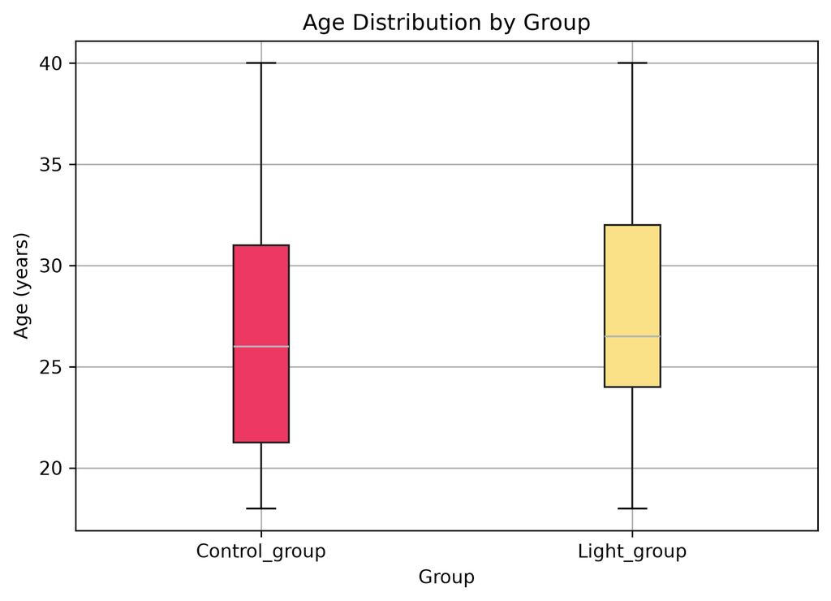

## What is the sex distribution by group?

The control group included 20 females and 18 males. The bright-light group included 19 females and 19 males.

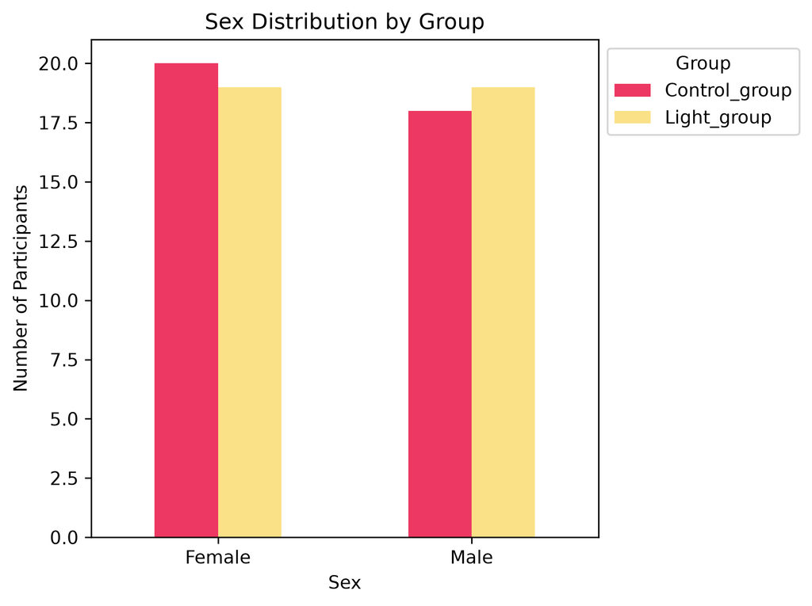

## Does the country of origin differ between the groups?

The control group included 24 participants from Australia and 14 from Sweden. The bright-light group included 16 participants from Australia and 22 from Sweden. The country distribution therefore differed between the groups. This difference may be relevant when interpreting the results. However, the difference alone does not establish that country is a confounding factor.

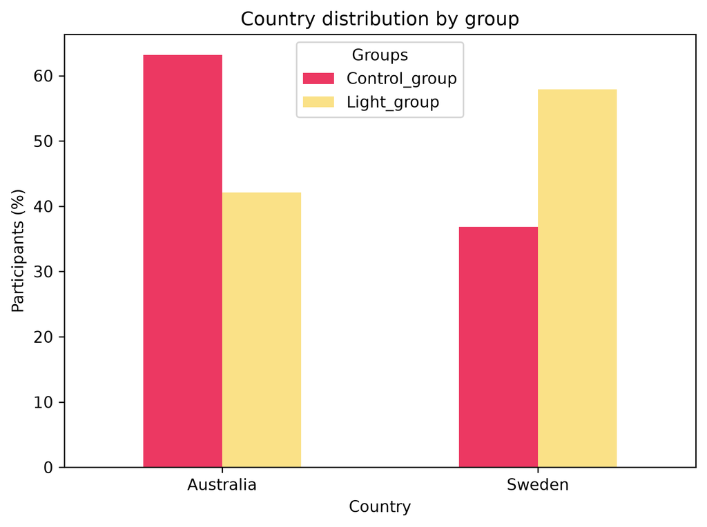

# Hippocampal volume

## Does hippocampal volume change from baseline to post-treatment?

A paired t-test compared hippocampal volume before and after the intervention in the same participants.

The change was statistically significant (*t* = 3.55, *p* < .001), indicating that hippocampal volume changed on average across the participants.

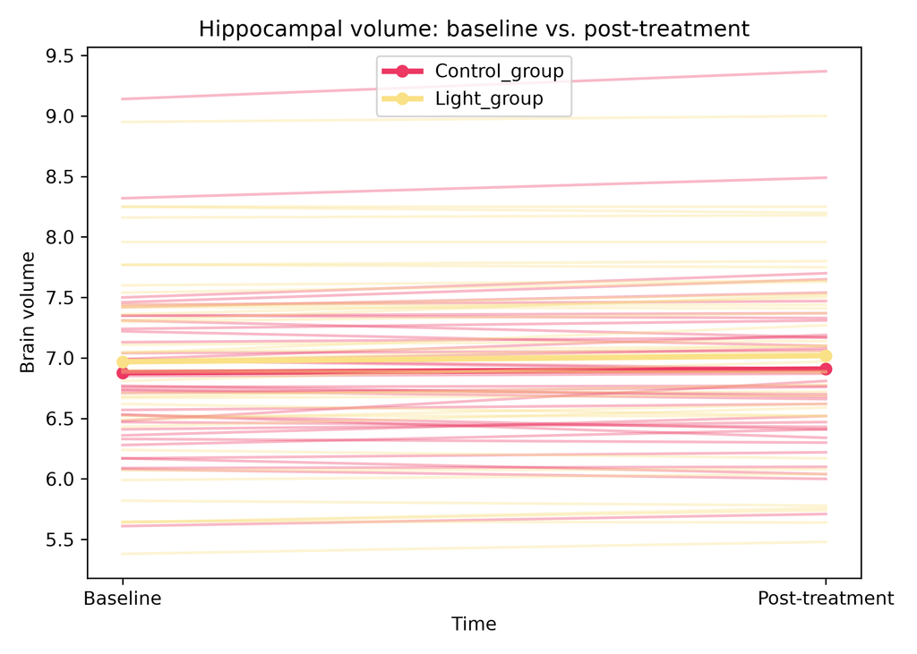

## Does this change differ between the control and bright-light groups?

A Welch’s independent t-test compared the change scores between groups.

The difference between groups was not statistically significant (*t* = -0.90, *p* = .374). There was insufficient evidence that hippocampal volume change differed between the control and bright-light groups.

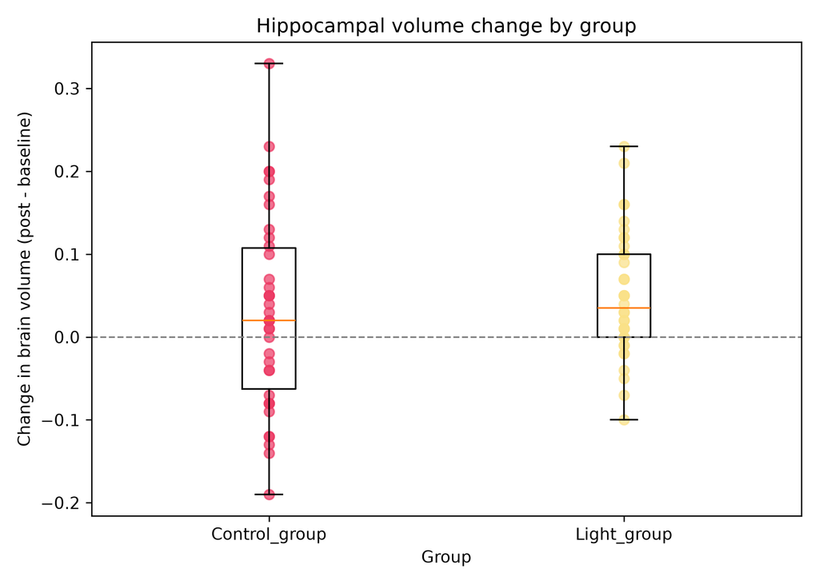

# Amygdala volume

## Does amygdala volume change from baseline to post-treatment?

A paired t-test compared amygdala volume before and after the intervention in the same participants.

The change was statistically significant (*t* = 4.05, *p* < .001), indicating that amygdala volume changed on average across the participants.

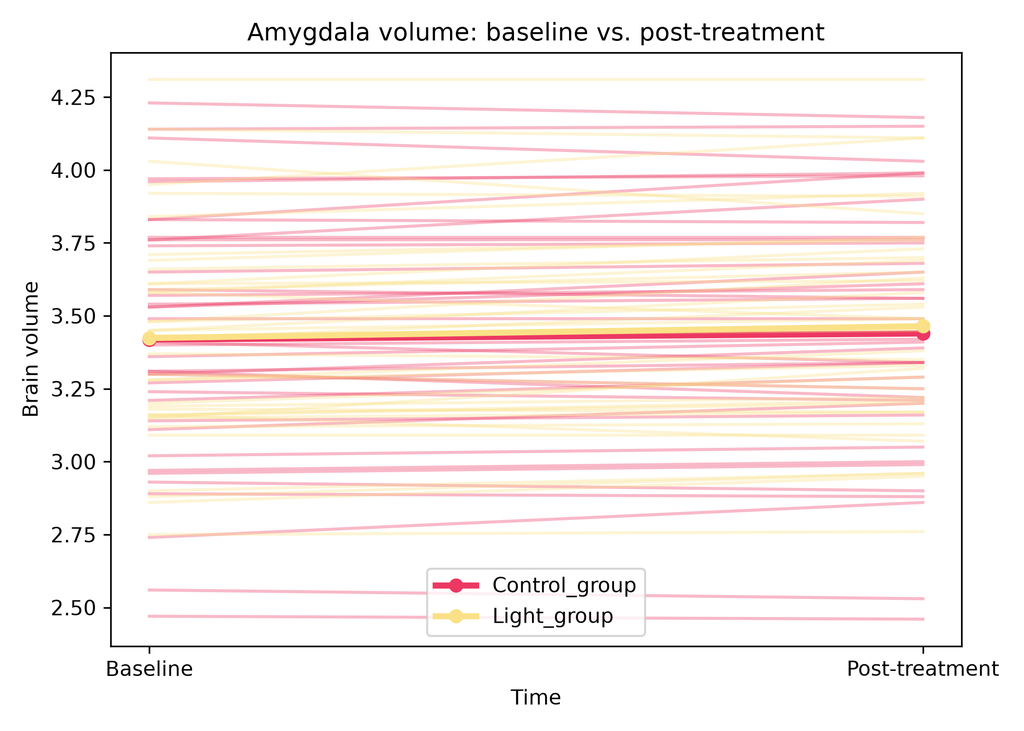

## Does this change differ between the control and bright-light groups?

A Welch’s independent t-test compared amygdala volume change between groups.

The difference between groups was not statistically significant (*t* = -1.29, *p* = .203). There was insufficient evidence that amygdala volume change differed between the control and bright-light groups.

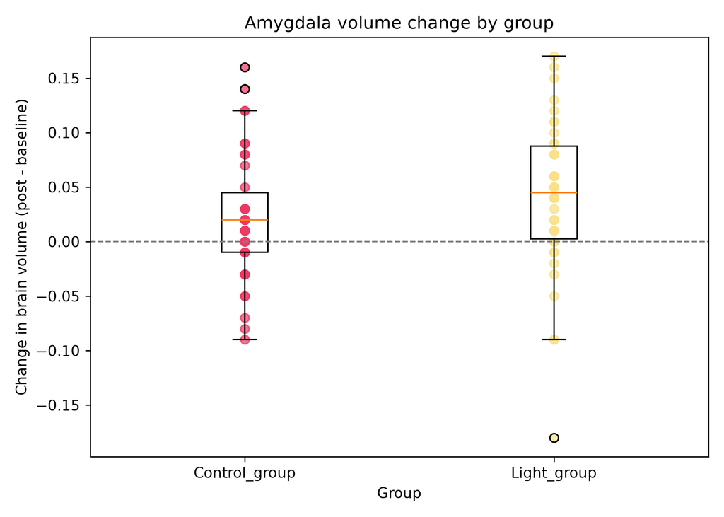

# Relationship between hippocampal and amygdala volume changes

## Are changes in hippocampal volume associated with changes in amygdala volume?

A Pearson correlation examined the relationship between the changes in the two brain regions.

The correlation was weak and positive (*r* = .158, *p* = .172). The association was not statistically significant, so there was insufficient evidence of a linear relationship between changes in the two brain regions.

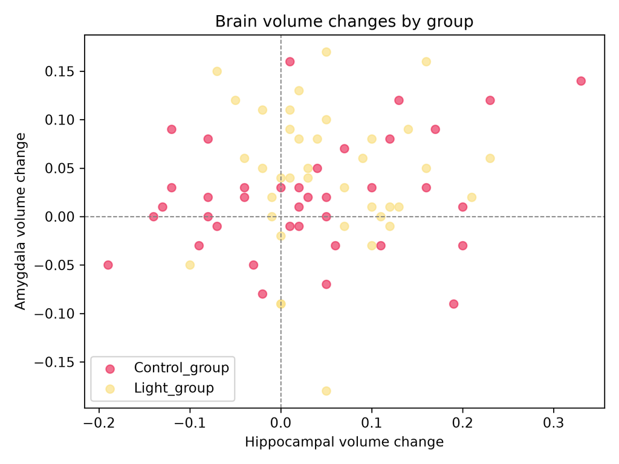

# Conclusion

Hippocampal and amygdala volumes changed significantly from baseline to post-treatment when participants were considered together. However, neither region showed a significant difference in volume change between the control and bright-light groups.

The correlation between changes in the two brain regions was weak and not statistically significant. Overall, there was insufficient evidence that bright-light therapy produced different changes in brain volume compared with the control condition.